# Homework 6

Alice Tivarovsky

11/16/2019

Setup code:

```r
library(tidyverse)
library(modelr)
library(MASS)
```

```r
library(patchwork)

set.seed(1)

knitr::opts_chunk$set(
    echo = TRUE,
    warning = FALSE,
  out.width = "90%"
)
options(
  ggplot2.continuous.colour = "viridis",
  ggplot2.continuous.fill = "viridis"
)
scale_colour_discrete = scale_colour_viridis_d
scale_fill_discrete = scale_fill_viridis_d
theme_set(theme_minimal() + theme(legend.position = "bottom"))
```

## Problem 1

### Data tidying and analysis

Loading and tidying birthweight dataset:

```r
bwt_data =
  read_csv("./data/birthweight.csv") %>%
  mutate(
    babysex = as_factor(babysex),
    frace = as_factor(frace),
    malform = as_factor(malform),
    mrace = as_factor(mrace)
  )
```

The resulting dataset contains 4342 observations across 20 variables. Numerical variables were converted to categorical variables based on the data dictionary using as_factor.

Next, we check for missing values using purrr:

```r
bwt_data %>%
  map_df(~sum(is.na(.)))
```

```
## # A tibble: 1 x 20
##   babysex bhead blength   bwt delwt fincome frace gaweeks malform menarche
##     <int> <int>   <int> <int> <int>   <int> <int>   <int>   <int>    <int>
## 1       0     0       0     0     0       0     0       0       0        0
## # … with 10 more variables: mheight <int>, momage <int>, mrace <int>,
## #   parity <int>, pnumlbw <int>, pnumsga <int>, ppbmi <int>, ppwt <int>,
## #   smoken <int>, wtgain <int>
```

We confirm there are no missing values in the dataset.

### Model-building using AIC

Next, we use stepwise AIC model-building analysis, which evaluates goodness-of-fit against model simplicity in a stepwise fashion to propose a linear regression model:

```r
full_model = lm(bwt ~. , data = bwt_data)

stepAIC(full_model, direction = "both")
```

```
## Start:  AIC=48717.83
## bwt ~ babysex + bhead + blength + delwt + fincome + frace + gaweeks +
##     malform + menarche + mheight + momage + mrace + parity +
##     pnumlbw + pnumsga + ppbmi + ppwt + smoken + wtgain
##
##
## Step:  AIC=48717.83
## bwt ~ babysex + bhead + blength + delwt + fincome + frace + gaweeks +
##     malform + menarche + mheight + momage + mrace + parity +
##     pnumlbw + pnumsga + ppbmi + ppwt + smoken
##
##
## Step:  AIC=48717.83
## bwt ~ babysex + bhead + blength + delwt + fincome + frace + gaweeks +
##     malform + menarche + mheight + momage + mrace + parity +
##     pnumlbw + ppbmi + ppwt + smoken
##
##
## Step:  AIC=48717.83
## bwt ~ babysex + bhead + blength + delwt + fincome + frace + gaweeks +
##     malform + menarche + mheight + momage + mrace + parity +
##     ppbmi + ppwt + smoken
##
##            Df Sum of Sq       RSS   AIC
## - frace     4    124365 320848704 48712
## - malform   1      1419 320725757 48716
## - ppbmi     1      6346 320730684 48716
## - momage    1     28661 320752999 48716
## - mheight   1     66886 320791224 48717
## - menarche  1    111679 320836018 48717
## - ppwt      1    131132 320855470 48718
## <none>                  320724338 48718
## - fincome   1    193454 320917792 48718
## - parity    1    413584 321137922 48721
## - mrace     3    868321 321592659 48724
## - babysex   1    853796 321578134 48727
## - gaweeks   1   4611823 325336161 48778
## - smoken    1   5076393 325800732 48784
## - delwt     1   8008891 328733230 48823
## - blength   1 102050296 422774634 49915
```

[output cut: 103 more lines]

```
## - fincome   1    245637 321232048 48707
## + momage    1     11698 320974714 48707
## + ppbmi     1      8823 320977589 48707
## + malform   1      1884 320984528 48707
## - parity    1    422770 321409181 48709
## + frace     4    128726 320857686 48712
## - babysex   1    846134 321832545 48715
## - mheight   1   1012240 321998651 48717
## - ppwt      1   2907049 323893461 48743
## - gaweeks   1   4662501 325648912 48766
## - smoken    1   5073849 326060260 48771
## - delwt     1   8137459 329123871 48812
## - mrace     3  14683609 335670021 48894
## - blength   1 102191779 423178191 49903
## - bhead     1 106779754 427766166 49950
```

```
##
## Call:
## lm(formula = bwt ~ babysex + bhead + blength + delwt + fincome +
##     gaweeks + mheight + mrace + parity + ppwt + smoken, data = bwt_data)
##
## Coefficients:
## (Intercept)     babysex2        bhead      blength        delwt
##   -6098.822       28.558      130.777       74.947        4.107
##     fincome      gaweeks      mheight       mrace2       mrace3
##       0.318       11.592        6.594     -138.792      -74.887
##      mrace4       parity         ppwt       smoken
##    -100.678       96.305       -2.676       -4.843
```

AIC analysis concludes that variables babysex, bhead, blength, delwt, fincome, gaweeks, mheight, mrace, parity, ppwt, and smoken are valuable predictors in the model. We use this model to fit a regression line:

```r
aic_model =
  bwt_data %>%
  lm(bwt ~ babysex + bhead + blength + delwt + fincome + gaweeks + mheight + mrace + parity + ppwt + smoken, data = .)
```

The resulting model has a strong R-squared of 71.81% and a significant global F-test (p-value = 0).

Next we plot the residuals versus the fitted values.

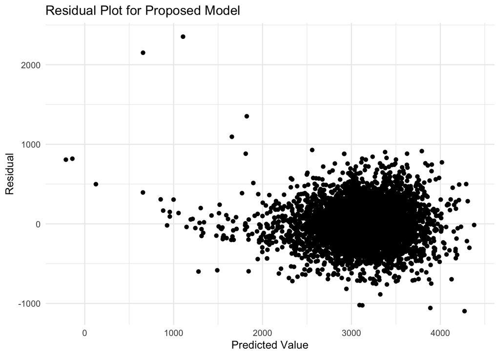

```r
bwt_data %>%
  add_residuals(aic_model) %>%
  add_predictions(aic_model) %>%
  ggplot(aes(x = pred, y = resid)) +
  geom_point() +
  labs(
    title = "Residual Plot for Proposed Model",
    x = "Predicted Value",
    y = "Residual"
  )
```

The residual plot resulting from the proposed model indicates potential problems with the model, particularly at values below 1500 grams, where the residuals appear to follow a non-random pattern.

### Cross-Validation

Next we use cross-validation methods to compare the proposed model to two other models.

First we create the testing and training datasets:

```r
cv_bwt =
  crossv_mc(bwt_data, 100)
```

Next, we use the datasets to fit two more candidate models: one that uses only the main effects of length at birth and gestational age, and one using head circumference, length, sex, and all associated interactions. We create a new dataframe using the computed prediction errors from the three candidate models.

```r
cv_bwt =
  cv_bwt %>%
  mutate(model_a = map(train, ~lm(bwt ~ blength + gaweeks, data = .x)),
         model_b = map(train, ~lm(bwt ~ bhead + blength + babysex + bhead*blength + bhead*babysex + blength*babysex + blength*babysex*bhead, data = .x)),
         aic_model = map(train, ~lm(bwt ~ babysex + bhead + blength + delwt + fincome + gaweeks + mheight + mrace + parity + ppwt + smoken, data = .))
  ) %>%
  mutate(rmse_a = map2_dbl(model_a, test, ~rmse(model = .x, data = .y)),
         rmse_b = map2_dbl(model_b, test, ~rmse(model = .x, data = .y)),
         rmse_aic = map2_dbl(aic_model, test, ~rmse(model = .x, data = .y)))
```

Finally, we generate comparison plots using rmse:

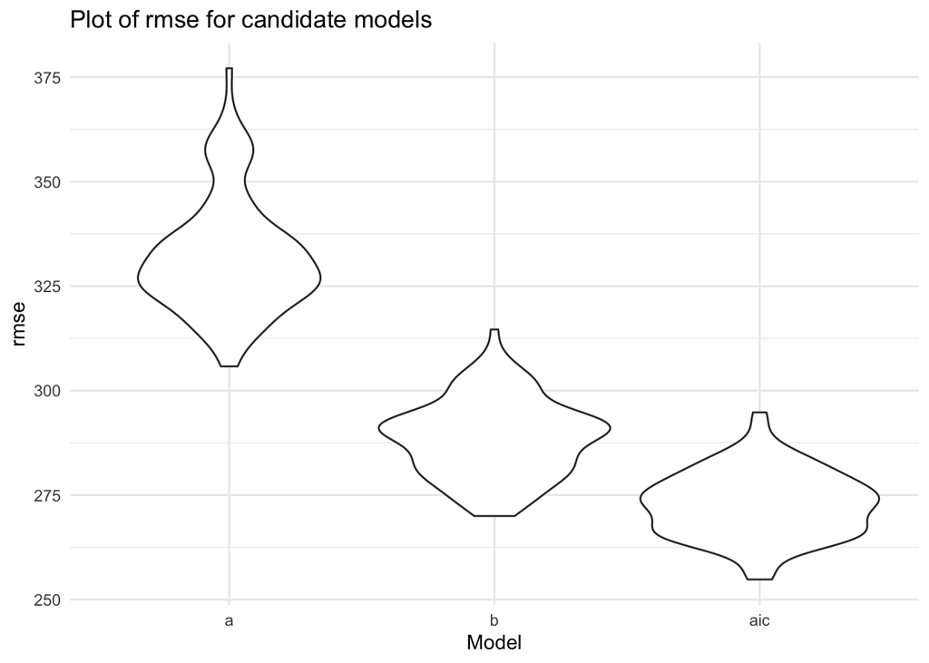

```r
error_plot =
  cv_bwt %>%
  dplyr::select(starts_with("rmse")) %>%
  pivot_longer(
    everything(),
    names_to = "model",
    values_to = "rmse",
    names_prefix = "rmse_") %>%
  mutate(model = fct_inorder(model)) %>%
  ggplot(aes(x = model, y = rmse)) +
  geom_violin() +
  labs(
    title = "Plot of rmse for candidate models",
    x = "Model",
    y = "rmse"
  )

error_plot
```

Based on the rmse plot, the original model built from AIC analysis is the best model since, overall, it produces the smallest prediction errors.

# Problem 2

This problem will be completed using data from the rnoaa package. We load and tidy the data:

```r
weather_df =
  rnoaa::meteo_pull_monitors(c("USW00094728", "USC00519397", "USS0023B17S"),
                      var = c("PRCP", "TMIN", "TMAX"),
                      date_min = "2017-01-01",
                      date_max = "2017-12-31") %>%
  mutate(
    name = recode(id, USW00094728 = "CentralPark_NY",
                      USC00519397 = "Waikiki_HA",
                      USS0023B17S = "Waterhole_WA"),
    tmin = tmin / 10,
    tmax = tmax / 10) %>%
  dplyr::select(name, id, everything())
```

```
## file path:          /Users/AliceTivarovsky/Library/Caches/rnoaa/ghcnd/USW00094728.dly
```

```
## file last updated:  2019-09-26 10:27:16
```

```
## file min/max dates: 1869-01-01 / 2019-09-30
```

```
## file path:          /Users/AliceTivarovsky/Library/Caches/rnoaa/ghcnd/USC00519397.dly
```

```
## file last updated:  2019-09-26 10:27:29
```

```
## file min/max dates: 1965-01-01 / 2019-09-30
```

```
## file path:          /Users/AliceTivarovsky/Library/Caches/rnoaa/ghcnd/USS0023B17S.dly
```

```
## file last updated:  2019-09-26 10:27:33
```

```
## file min/max dates: 1999-09-01 / 2019-09-30
```

```r
weather_df
```

```
## # A tibble: 1,095 x 6
##    name           id          date        prcp  tmax  tmin
##    <chr>          <chr>       <date>     <dbl> <dbl> <dbl>
##  1 CentralPark_NY USW00094728 2017-01-01     0   8.9   4.4
##  2 CentralPark_NY USW00094728 2017-01-02    53   5     2.8
##  3 CentralPark_NY USW00094728 2017-01-03   147   6.1   3.9
##  4 CentralPark_NY USW00094728 2017-01-04     0  11.1   1.1
##  5 CentralPark_NY USW00094728 2017-01-05     0   1.1  -2.7
##  6 CentralPark_NY USW00094728 2017-01-06    13   0.6  -3.8
##  7 CentralPark_NY USW00094728 2017-01-07    81  -3.2  -6.6
##  8 CentralPark_NY USW00094728 2017-01-08     0  -3.8  -8.8
##  9 CentralPark_NY USW00094728 2017-01-09     0  -4.9  -9.9
## 10 CentralPark_NY USW00094728 2017-01-10     0   7.8  -6
## # … with 1,085 more rows
```

Using the `weather_df` dataset, we draw 5000 bootstrap samples and fit a linear regression with `tmax` as the response and `tmin` as the predictor. We are interested in the model r-squared and the value of log(beta_0 * beta_1).

Here, we draw the bootstrap samples and create a dataframe containing the values of interest.

```r
boot_weather =
weather_df %>%
  modelr::bootstrap(n = 5000) %>%
  mutate(
    models = map(strap, ~lm(tmax ~ tmin, data = .x)),
    results = map(models, broom::tidy),
    glance = map(models, broom::glance)) %>%
  dplyr::select(results, glance) %>%
  unnest(results, glance) %>%
  janitor::clean_names() %>%
  dplyr::select(term,estimate, r_squared) %>%
  pivot_wider(
    names_from = term,
    values_from = estimate)  %>%
  janitor::clean_names() %>%
  mutate(log_est = log(intercept * tmin))
```

Next we plot the distributions of r-squared and log(beta_0 * beta_1).

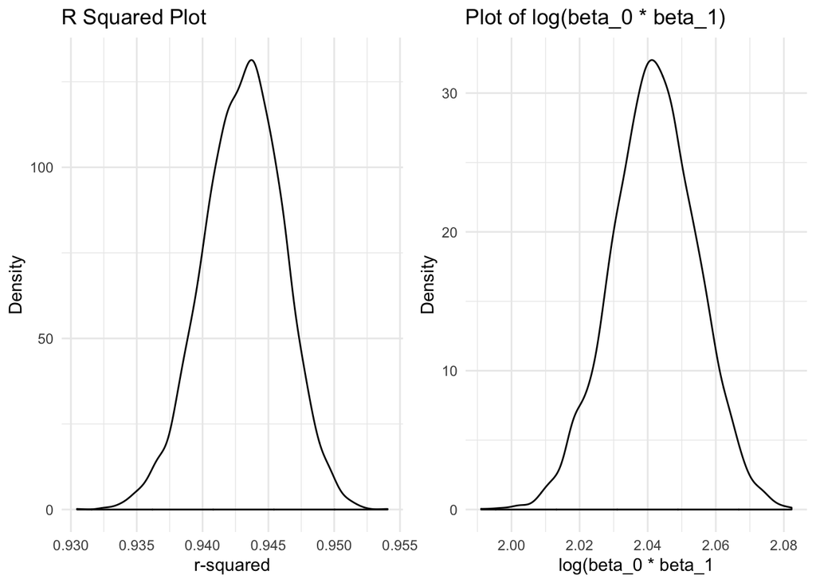

```r
r_squared_plot =
  boot_weather %>%
  ggplot(aes(x = r_squared)) +
  geom_density() +
  labs(
    title = "R Squared Plot",
    x = "r-squared",
    y = "Density"
  )

log_est_plot =
  boot_weather %>%
  ggplot(aes(x = log_est)) +
  geom_density() +
  labs(
    title = "Plot of log(beta_0 * beta_1)",
    x = "log(beta_0 * beta_1",
    y = "Density"
  )

(r_squared_plot + log_est_plot)
```

Both values are normally distributed with small “shoulders” on the left side, most likely due to the influence of outliers.

Finally, we compute 2.5% and 97.5% quantiles to provide a 95% confidence interval for `r_squared` and `log_est`.

```r
pull(boot_weather, r_squared) %>% quantile(c(0.025, .975))
```

```
##      2.5%     97.5%
## 0.9368292 0.9487296
```

```r
pull(boot_weather, log_est) %>% quantile(c(0.025, .975))
```

```
##     2.5%    97.5%
## 2.017156 2.065878
```

Based on the bootstrap sample, the 95% confidence interval for r-squared is (0.9368292, 0.9487296) and the 95% confidence interval for log(beta_0 * beta_1) is (2.017156, 2.065878).